# Session 2

## Import the fpp library

library(fpp)

library(tseries)

library(ggplot2)

library(forecast)

## Example I - Regression Example

#### tslm() -

Fit a linear model with time series components tslm is used to fit linear models to time series including trend and seasonality components See ?tslm

#### usconsumption dataset

Growth rates of personal consumption and personal income in the USA.

Description: Percentage changes in quarterly personal consumption expenditure and personal disposable income for the US, 1970 to 2010.

See ?usconsumption for additional information

### Plot data

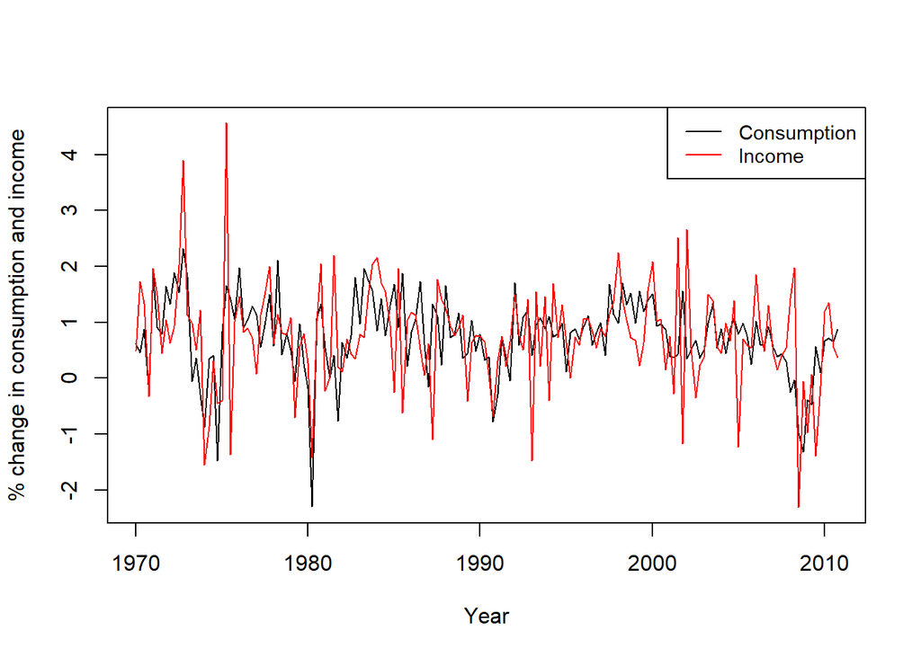

```r
plot(usconsumption, ylab="% change in consumption and income",
     plot.type="single", col=1:2, xlab="Year")
legend("topright", legend=c("Consumption","Income"),
       lty=1, col=c(1,2), cex=.9)
```

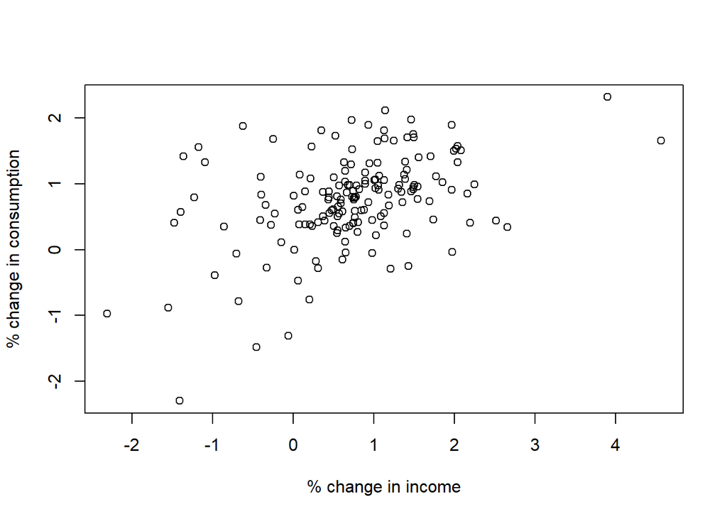

```r
plot(consumption ~ income, data=usconsumption,
     ylab="% change in consumption", xlab="% change in income")
```

### Fit linear timeseries model

```r
fit <- tslm(consumption ~ income, data=usconsumption)
summary(fit)
```

```
##
## Call:
## tslm(formula = consumption ~ income, data = usconsumption)
##
## Residuals:
##     Min      1Q  Median      3Q     Max
## -2.3681 -0.3237  0.0266  0.3436  1.5581
##
## Coefficients:
##             Estimate Std. Error t value Pr(>|t|)
## (Intercept)  0.52062    0.06231   8.356 2.79e-14 ***
## income       0.31866    0.05226   6.098 7.61e-09 ***
## ---
## Signif. codes:  0 '***' 0.001 '**' 0.01 '*' 0.05 '.' 0.1 ' ' 1
##
## Residual standard error: 0.6274 on 162 degrees of freedom
## Multiple R-squared:  0.1867, Adjusted R-squared:  0.1817
## F-statistic: 37.18 on 1 and 162 DF,  p-value: 7.614e-09
```

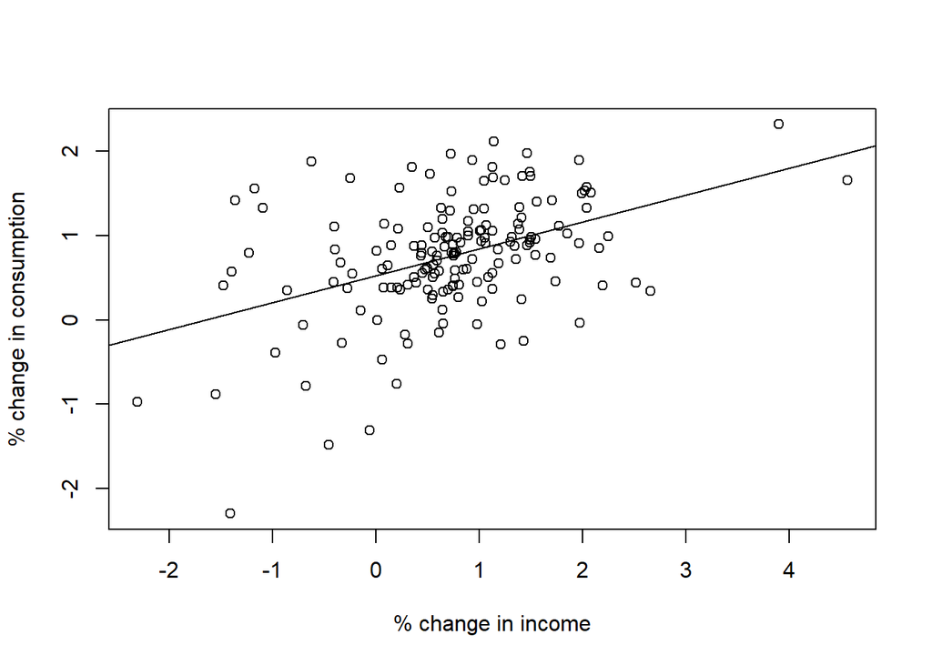

```r
plot(consumption ~ income, data=usconsumption,
     ylab="% change in consumption", xlab="% change in income")
abline(fit)
```

### Forecast consumption

Forecast consumption if there is a 2% growth in income for each of the quarters in 2011. Alternatively a 3% decline in income for each of the quarters may be of interest.

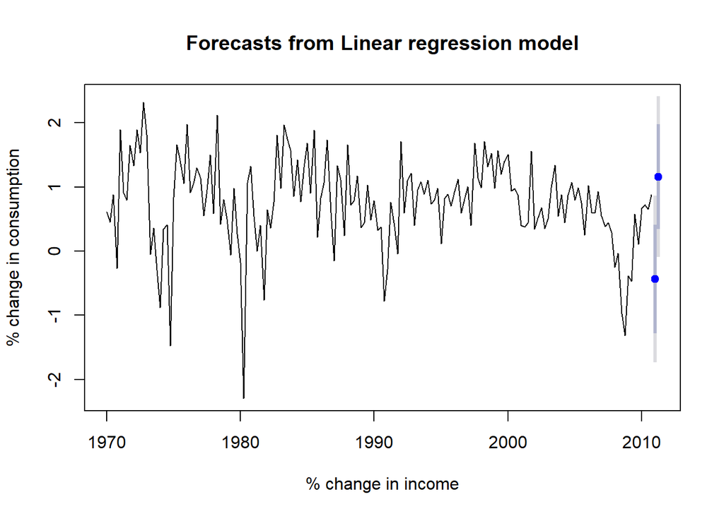

```r
fcast <- forecast(fit, newdata=data.frame(income=c(-3,2)))


plot(fcast, ylab="% change in consumption", xlab="% change in income")
```

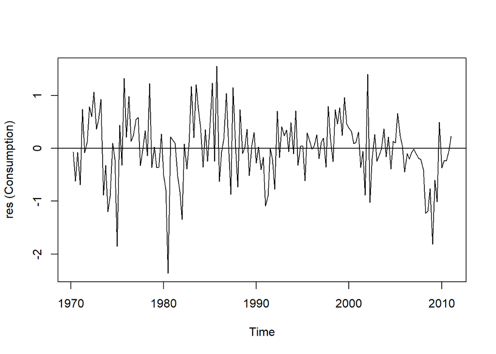

```r
res <- ts(resid(fit),s=1970.25,f=4)


plot.ts(res,ylab="res (Consumption)")
abline(0,0)
```

### Check Residuals

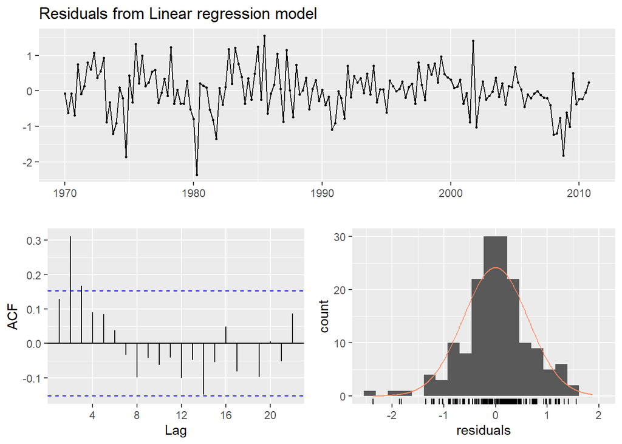

```
##
##  Breusch-Godfrey test for serial correlation of order up to 8
##
## data:  Residuals from Linear regression model
## LM test = 24.182, df = 8, p-value = 0.002136
```

```r
checkresiduals(fit)
```

```r
# p-value  < 0.05 ==> Accept Alternative hypothesis ==> Residuals are autocorrelated
```

## Example II - Classical Decomposition

#### decompose function

Classical Seasonal Decomposition by Moving Averages

Description: Decompose a time series into seasonal, trend and irregular components using moving averages. Deals with additive or multiplicative seasonal component.

See ?decompose for additional information

#### Exponential smoothing forecasts Functions

##### Level

ses(y, h = 10, level = c(80, 95), fan = FALSE, initial = c(“optimal”, “simple”), alpha = NULL, lambda = NULL, biasadj = FALSE, x = y, …)

##### Level + Trend

holt(y, h = 10, damped = FALSE, level = c(80, 95), fan = FALSE, initial = c(“optimal”, “simple”), exponential = FALSE, alpha = NULL, beta = NULL, phi = NULL, lambda = NULL, biasadj = FALSE, x = y, …)

##### Level + Trend + Seasonality

hw(y, h = 2 * frequency(x), seasonal = c(“additive”, “multiplicative”), damped = FALSE, level = c(80, 95), fan = FALSE, initial = c(“optimal”, “simple”), exponential = FALSE, alpha = NULL, beta = NULL, gamma = NULL, phi = NULL, lambda = NULL, biasadj = FALSE, x = y, …)

#### austourists Dataset

data<-austourists

International Tourists to Australia: Total visitor nights. Description: Quarterly visitor nights spent by international tourists to Australia. 1999-2010

See ?austourists for additional information

### Load and plot data

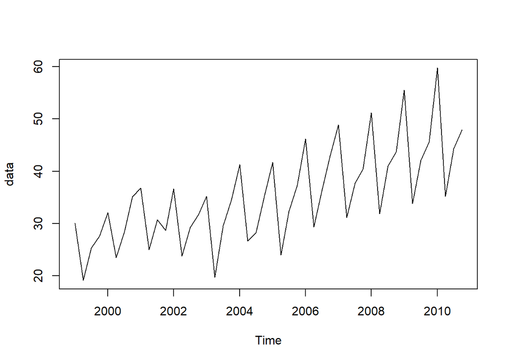

```r
data<-austourists

plot(data)
```

### decompose

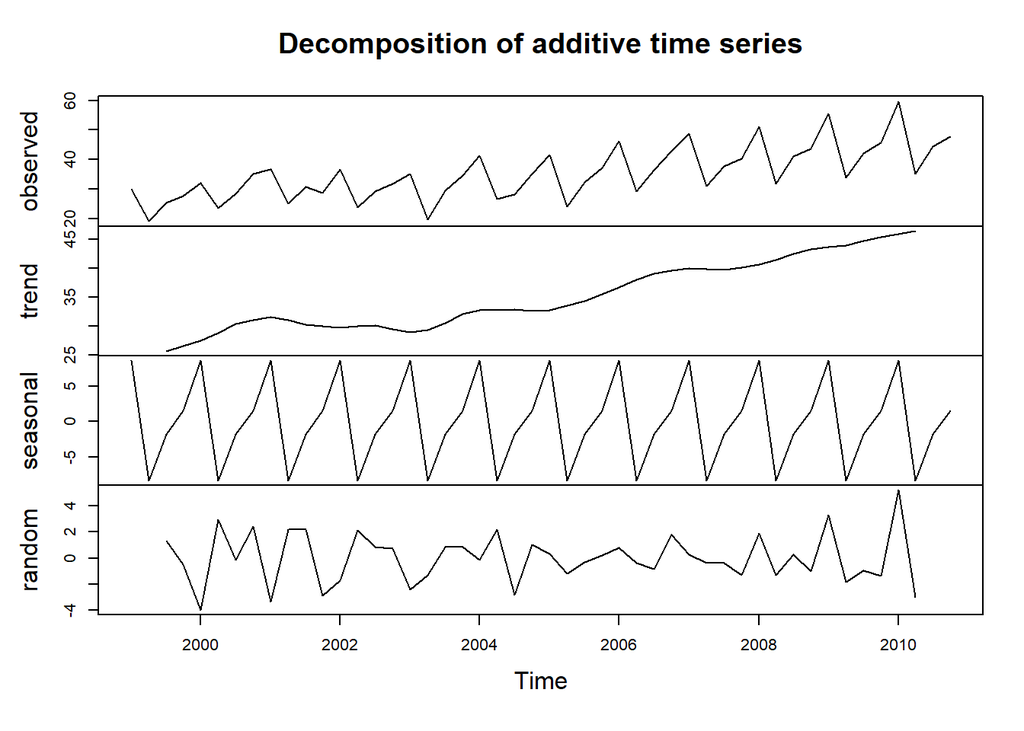

```r
fit_add <- decompose(data, type="additive")

plot(fit_add)
```

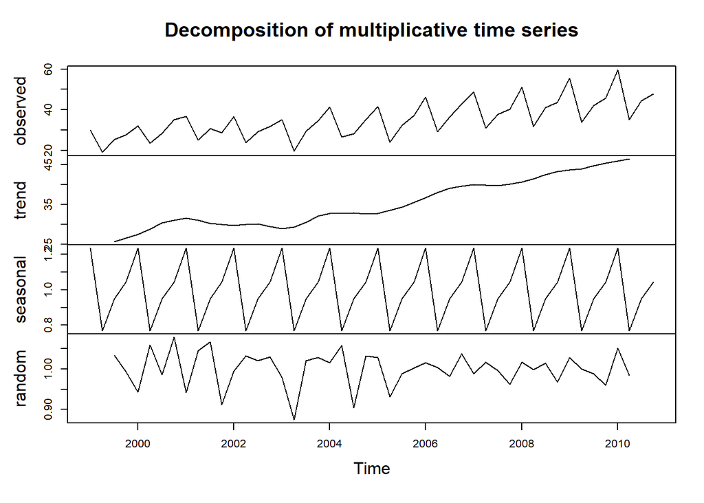

```r
fit_mult <- decompose(data, type="multiplicative")

plot(fit_mult)
```

### Fit Exponential smoothing forecasts

```r
fit_hw <- hw(data, h=24, seasonal="mult",
           damped=TRUE)
summary(fit_hw)
```

```
##
## Forecast method: Damped Holt-Winters' multiplicative method
##
## Model Information:
## Damped Holt-Winters' multiplicative method
##
## Call:
##  hw(y = data, h = 24, seasonal = "mult", damped = TRUE)
##
##   Smoothing parameters:
##     alpha = 0.5105
##     beta  = 1e-04
##     gamma = 1e-04
##     phi   = 0.9795
##
##   Initial states:
##     l = 23.0818
##     b = 0.9438
##     s = 1.0393 0.951 0.7742 1.2355
##
##   sigma:  0.0689
##
##      AIC     AICc      BIC
## 278.9244 284.8703 297.6364
##
## Error measures:
##                      ME     RMSE      MAE       MPE     MAPE      MASE
## Training set -0.1722167 2.120519 1.571684 -1.020416 4.705302 0.5422378
##                    ACF1
## Training set 0.01576864
##
## Forecasts:
##         Point Forecast    Lo 80    Hi 80    Lo 95    Hi 95
## 2011 Q1       57.88330 52.77402 62.99257 50.06933 65.69726
## 2011 Q2       36.53719 32.91972 40.15465 31.00475 42.06962
## 2011 Q3       45.19886 40.29119 50.10653 37.69322 52.70450
## 2011 Q4       49.73665 43.90365 55.56964 40.81585 58.65744
## 2012 Q1       59.52267 52.06485 66.98050 48.11692 70.92843
## 2012 Q2       37.54346 32.55950 42.52742 29.92115 45.16577
## 2012 Q3       46.40960 39.92392 52.89528 36.49061 56.32859
## 2012 Q4       51.03271 43.56380 58.50162 39.61000 62.45542
## 2013 Q1       61.03185 51.71661 70.34710 46.78541 75.27829
## 2013 Q2       38.46982 32.36817 44.57146 29.13816 47.80148
## 2013 Q3       47.52419 39.71447 55.33390 35.58026 59.46811
## 2013 Q4       52.22584 43.35651 61.09517 38.66137 65.79031
## 2014 Q1       62.42117 51.48996 73.35238 45.70332 79.13901
## 2014 Q2       39.32260 32.23553 46.40967 28.48386 50.16133
## 2014 Q3       48.55025 39.56010 57.54039 34.80101 62.29948
## 2014 Q4       53.32421 43.19450 63.45392 37.83216 68.81626
## 2015 Q1       63.70014 51.30272 76.09757 44.73991 82.66037
## 2015 Q2       40.10765 32.12018 48.09512 27.89187 52.32344
## 2015 Q3       49.49482 39.41945 59.57018 34.08588 64.90376
## 2015 Q4       54.33535 43.04065 65.63005 37.06160 71.60910
## 2016 Q1       64.87754 51.11837 78.63671 43.83471 85.92037
## 2016 Q2       40.83036 32.00307 49.65764 27.33019 54.33052
## 2016 Q3       50.36437 39.27295 61.45579 33.40151 67.32723
## 2016 Q4       55.26618 42.87699 67.65537 36.31855 74.21381
```

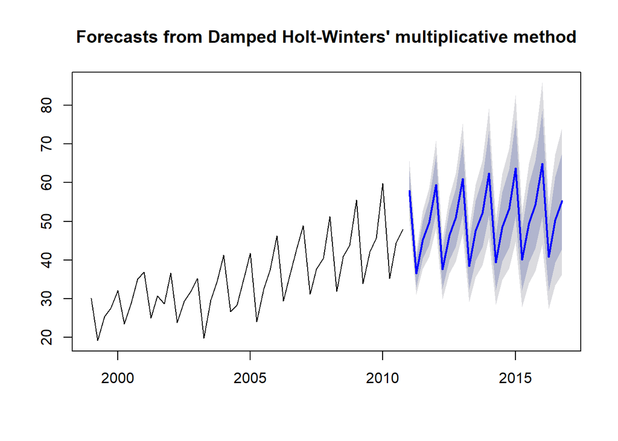

```r
plot(fit_hw)
```

### Check Residuals

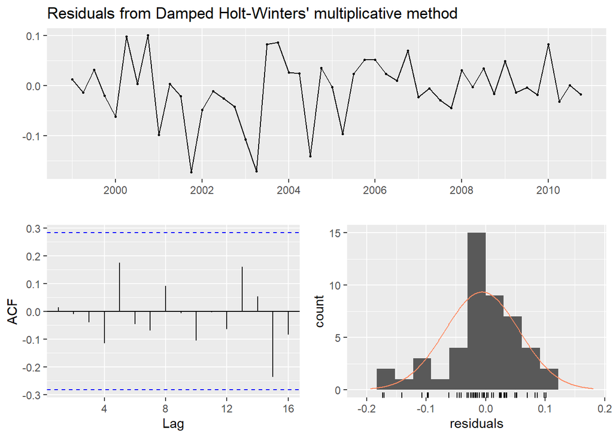

```
##
##  Ljung-Box test
##
## data:  Residuals from Damped Holt-Winters' multiplicative method
## Q* = 4.4383, df = 3, p-value = 0.2179
##
## Model df: 9.   Total lags used: 12
```

```r
checkresiduals(fit_hw)
```

## Example III - Seasonal Holt Winter

#### co2 Dataset

Mauna Loa Atmospheric CO2 Concentration Description: Atmospheric concentrations of CO2 are expressed in parts per million (ppm) and reported in the preliminary 1997 SIO manometric mole fraction scale.

### Plot data

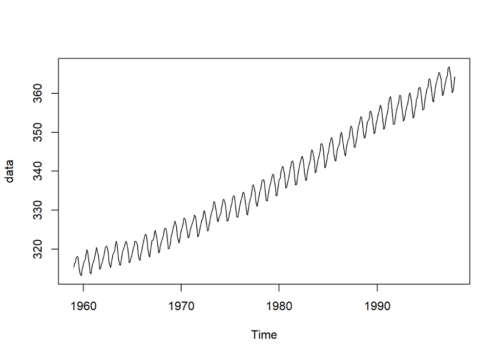

```r
data<-co2 # Mauna Loa Atmospheric CO2 Concentration
plot(data)
```

```r
m_add <- hw(data,seasonal = "additive",h=48) # or ?HoltWinters
m_multi <- hw(data,seasonal = "multiplicative",h=48) # or ?HoltWinters
m_Damped_add <- hw(data,seasonal = "additive",h=48, damped = TRUE) # or ?HoltWinters
```

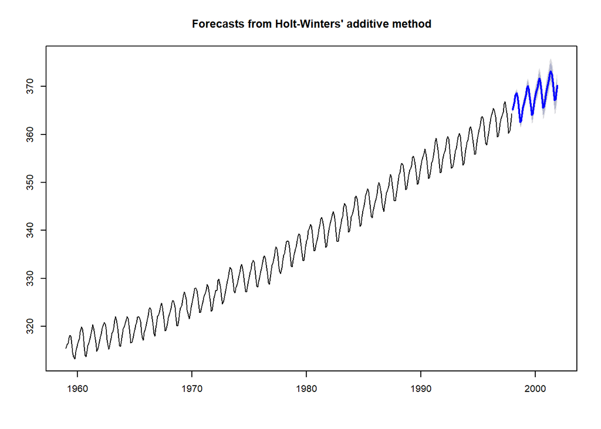

```r
par(mfrow=c(3,1), fig=c(0,1,0,1))
plot(m_add)
```

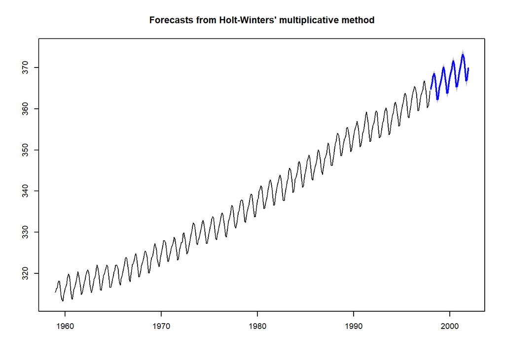

```r
plot(m_multi)
```

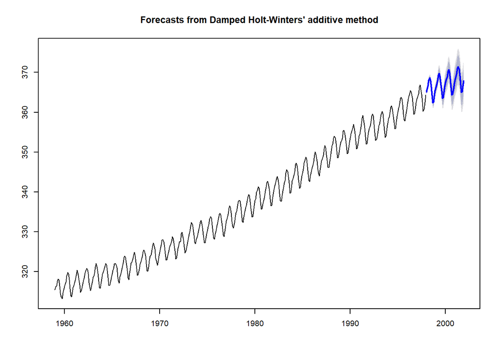

```r
plot(m_Damped_add)
```

### Smoothing parameters and Initial states

```r
m_add$model
```

```
## Holt-Winters' additive method
##
## Call:
##  hw(y = data, h = 48, seasonal = "additive")
##
##   Smoothing parameters:
##     alpha = 0.5785
##     beta  = 0.0061
##     gamma = 0.1373
##
##   Initial states:
##     l = 315.3303
##     b = 0.0801
##     s = -0.8174 -1.836 -3.024 -2.7715 -1.2671 0.7784
##            2.1746 2.702 2.1571 1.1912 0.6693 0.0433
##
##   sigma:  0.294
##
##      AIC     AICc      BIC
## 1749.350 1750.710 1819.874
```

```r
m_multi$model
```

```
## Holt-Winters' multiplicative method
##
## Call:
##  hw(y = data, h = 48, seasonal = "multiplicative")
##
##   Smoothing parameters:
##     alpha = 0.0974
##     beta  = 0.0029
##     gamma = 0.1178
##
##   Initial states:
##     l = 315.9361
##     b = 0.1051
##     s = 0.9989 0.9939 0.9901 0.9901 0.9973 1.002
##            1.0067 1.0079 1.0089 1.0043 1.001 0.9988
##
##   sigma:  0.0013
##
##      AIC     AICc      BIC
## 2104.996 2106.356 2175.520
```

```r
m_Damped_add$model
```

```
## Damped Holt-Winters' additive method
##
## Call:
##  hw(y = data, h = 48, seasonal = "additive", damped = TRUE)
##
##   Smoothing parameters:
##     alpha = 0.5183
##     beta  = 0.0388
##     gamma = 0.1618
##     phi   = 0.9798
##
##   Initial states:
##     l = 315.3338
##     b = 0.0718
##     s = -0.8014 -1.9621 -3.1556 -2.6888 -1.3148 0.8039
##            2.256 2.7946 2.4423 1.0257 0.7116 -0.1112
##
##   sigma:  0.3067
##
##      AIC     AICc      BIC
## 1790.004 1791.527 1864.676
```